# Analyse des données avec R

07 avril, 2022

## Objectifs de la formation

**Objectifs**

- Acquérir des compétences d’analyse de données
  - Méthodes
  - Démarches
- Se familiariser avec R et Rstudio
  - Mettre en oeuvre
  - Editer des rapports

**Modalités pédagogiques**

- Apprentissage par mise en situation
- Programme modulable selon vos questions

## Environnement R et Rstudio

## R

: environnement pour l’analyse de données et la visualisation

- R est un logiciel libre
- Site web : https://www.r-project.org
- Nov. 2021 : > 18 000 packages https://cran.r-project.org/
- Communautés R :
  - https://www.r-bloggers.com/,
  - https://rladies.org/,
  - https://r-toulouse.netlify.app/
  - https://stackoverflow.com/questions/
  - https://r-graph-gallery.com/

## Rstudio

[figure not shown]

: interface pour R (IDE : Integrated Development Environment)

- Site web : https://www.rstudio.com/
- Environnement ergonomique pour l’analyse de données
- Outils pour l’édition de rapport d’études
  - Rmarkdown : http://rmarkdown.rstudio.com/
- Préparation de la session de travail
  - Créez un projet pour l’analyse des données **maturity**
  - Installez (si besoin) le package **tidyverse**

## Importer des données

```r
fruit <- read.table(file="fruit.txt",stringsAsFactors=TRUE)
str(fruit)
```

```
'data.frame':   435 obs. of  12 variables:
 $ Poids     : num  48 40.2 42 47.4 35.2 60.5 66.7 44.1 44.5 43.6 ...
 $ Diam      : num  36.9 36.9 35.4 37.5 33.9 ...
 $ L         : num  64.2 58.1 61 56.4 59.7 ...
 $ a         : num  -6.78 -13.2 -6.71 5.43 -12.31 ...
 $ b         : num  42.4 39.1 36.8 34.8 40.3 ...
 $ Glucose   : num  1.28 1.3 2.69 2.28 1.17 1.4 1.19 1.34 1.24 1.21 ...
 $ Fructose  : num  0.52 0.47 0.91 0.74 0.5 0.57 0.46 0.51 0.52 0.58 ...
 $ Saccharose: num  2.48 1.71 5.46 4.27 1.72 4.01 3.33 2.29 2.82 1.74 ...
 $ Citrate   : num  36.8 37.9 38.5 34.9 36.1 ...
 $ Malate    : num  3.95 4.98 4.57 5.33 4.15 4.56 4.94 5.24 4.6 4.04 ...
 $ Variete   : Factor w/ 4 levels "37","bl","go",..: 1 1 1 1 1 1 1 1 1 1 ...
 $ Maturite  : Factor w/ 3 levels "Faible","Forte",..: 1 1 1 1 1 1 1 1 1 1 ...
```

## Explorer, visualiser

## Effectifs par groupes

```r
tab <- fruit %>%
    group_by(Variete) %>%
    tally()
tab %>% t() %>% kbl(caption="Effectifs par variété") %>%
  kable_paper(bootstrap_options = "striped", full_width = F)
```

Effectifs par variété

| Variete | 37 | bl | go | mo |
| --- | --- | --- | --- | --- |
| n | 107 | 108 | 102 | 118 |

## Diagramme en barres

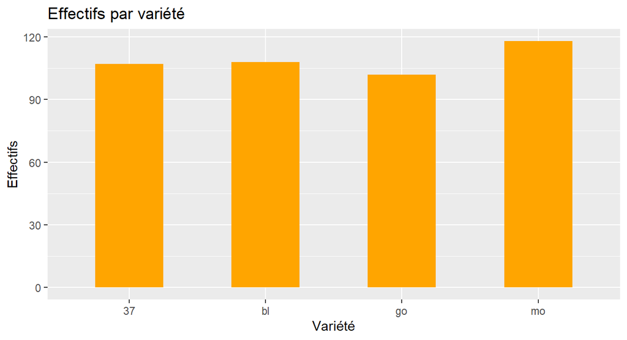

```r
fruit %>% ggplot() +
  geom_bar(aes(x = Variete),fill="orange",width=0.5) +
  ggtitle("Effectifs par variété") + xlab("Variété") + ylab("Effectifs")
```

## Résumé statistique

```r
tab <- fruit %>% summarise(Mean=mean(Poids),
              Sd=sd(Poids),
              Min=min(Poids),
              Max=max(Poids))
tab %>% kbl(caption="Résumé statistique de Poids") %>%
  kable_paper(bootstrap_options = "striped", full_width = F)
```

Résumé statistique de Poids

| Mean | Sd | Min | Max |
| --- | --- | --- | --- |
| 60.6 | 11.7 | 35.2 | 104 |

## Histogramme

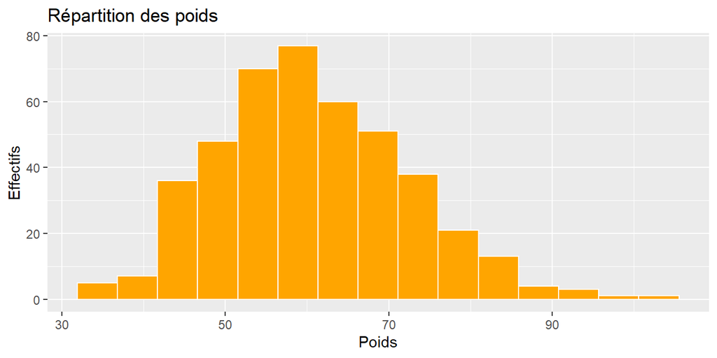

```r
fruit %>% ggplot() + aes(x = Poids) +
  geom_histogram(fill="orange",bins=15,col="white") +
  ggtitle("Répartition des poids") + xlab("Poids") +
  ylab("Effectifs")
```

## Résumé statistique par groupe

```r
tab <- fruit %>% group_by(Variete) %>%
  summarise(Mean=mean(Poids),Sd=sd(Poids),
              Min=min(Poids),Max=max(Poids))
tab %>% kbl(caption="Résumé statistique de Poids") %>%
  kable_paper(bootstrap_options = "striped", full_width = F)
```

Résumé statistique de Poids

| Variete | Mean | Sd | Min | Max |
| --- | --- | --- | --- | --- |
| 37 | 56.0 | 9.43 | 35.2 | 73.5 |
| bl | 53.2 | 7.76 | 38.7 | 77.4 |
| go | 61.6 | 10.63 | 41.3 | 96.7 |
| mo | 70.7 | 9.91 | 47.3 | 103.9 |

## Boites de dispersion

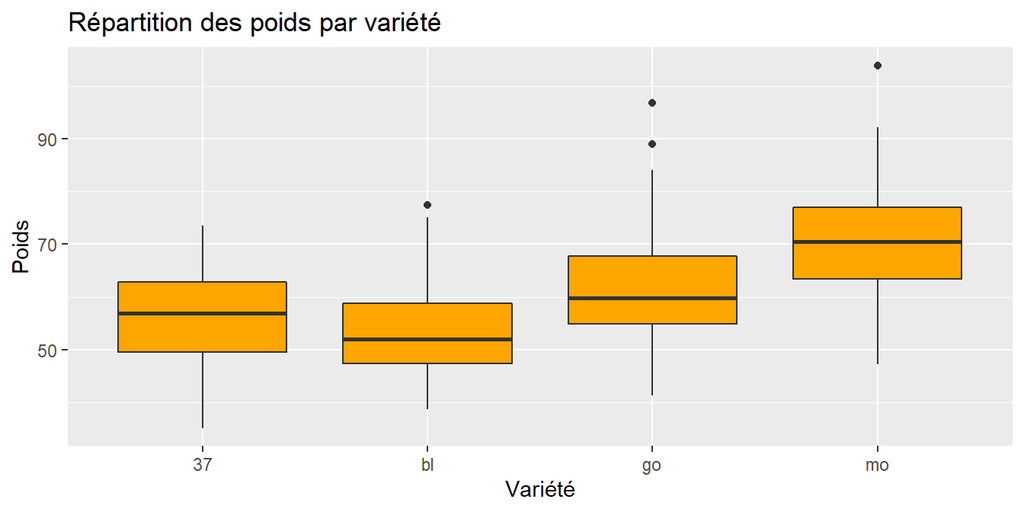

```r
fruit %>% ggplot() +
  geom_boxplot(aes(x=Variete,y=Poids),fill="orange") +
  ggtitle("Répartition des poids par variété") +
  xlab("Variété") + ylab("Poids")
```

## Nuage de points

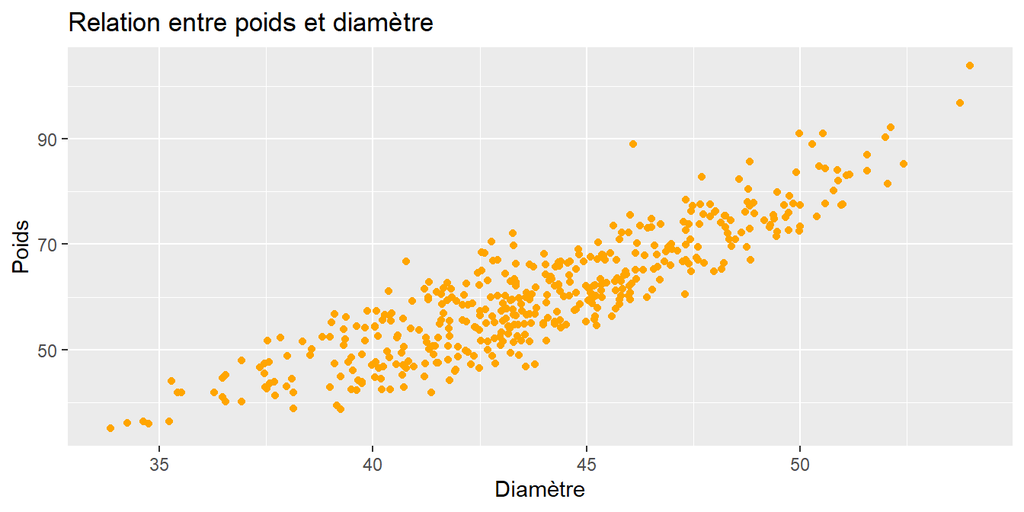

```r
p <- fruit %>% ggplot() + geom_point(aes(x=Diam,y=Poids),col="orange") +
  ggtitle("Relation entre poids et diamètre") + xlab("Diamètre") + ylab("Poids")
p
```

## Tendance linéaire

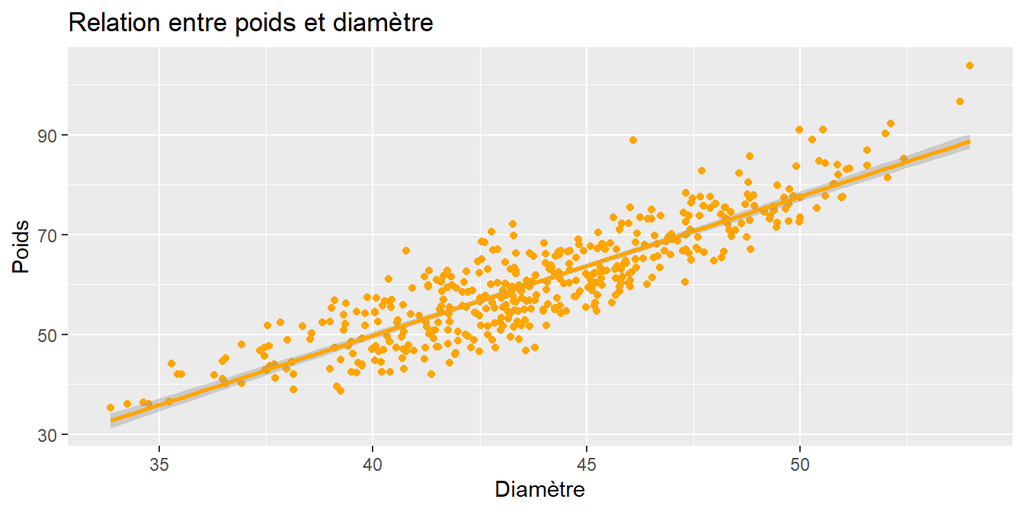

```r
p + geom_smooth(method="lm",aes(x=Diam,y=Poids),col="orange")
```

## Nuage de points par groupe

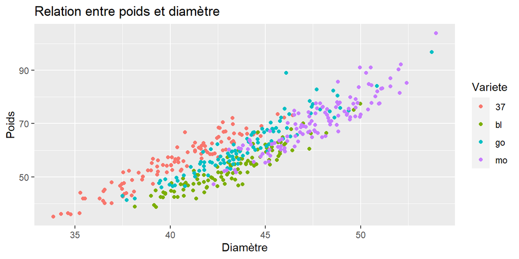

```r
p <- fruit %>% ggplot() + geom_point(aes(x=Diam,y=Poids,col=Variete)) +
  ggtitle("Relation entre poids et diamètre") + xlab("Diamètre") + ylab("Poids")
p
```

## Tendance linéaire par groupe

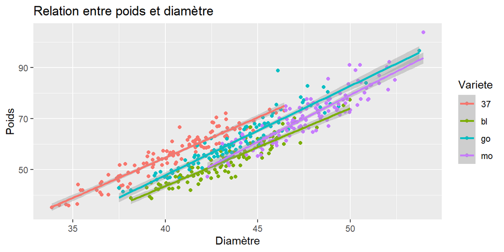

```r
p + geom_smooth(method="lm",aes(x=Diam,y=Poids,col=Variete))
```

## Tester un effet

## Principes généraux

**Y-a-t’il un effet de ceci sur cela ?**

Effet de ceci sur cela : lien entre ceci et cela à l’échelle d’une population

**Exemples** :

- Les poids moyens sont-ils les mêmes pour toutes les variétés ?
- Le diamètre dépend-il de l’indice de clarté *L* ?

**Dans ces deux problématiques, que sont**

- **la population visée ?**
- **ceci (variable explicative) ?**
- **cela (variable à expliquer) ?**

## Effet groupe

## Exemple

**Les poids moyens des fruits par variété sont-il différents ?**

```r
tab <- fruit %>% group_by(Variete) %>% summarise(Mean=mean(Poids))
tab %>% mutate(Mean=round(Mean,digits=2)) %>% t() %>%
  kbl(caption="Résumé statistique de Poids") %>%
  kable_paper(bootstrap_options = "striped", full_width = F)
```

Résumé statistique de Poids

| Variete | 37 | bl | go | mo |
| --- | --- | --- | --- | --- |
| Mean | 56.0 | 53.2 | 61.6 | 70.7 |

Les poids moyens par variété **sont différents**.

Le sont-ils **suffisamment** pour conclure que les différences entre variétés existent à l’échelle de toute la production ?

## Modèle d’analyse de la variance à un facteur

**Ajustement du modèle :**

```r
mod1 <- lm(Poids~Variete,data=fruit)
coef(mod1)
```

```
(Intercept)   Varietebl   Varietego   Varietemo
      55.99       -2.83        5.63       14.68
```

**Quelle est la variété pour laquelle les fruits sont les plus lourds ?**

## Modèle nul

Sous l’hypothèse d’**absence effet** (modèle nul)

```r
mod0 <- lm(Poids~1,data=fruit)
coef(mod0)
```

```
(Intercept)
       60.6
```

**Pourquoi l’estimation de ‘(Intercept)’ n’est pas la même avec les modèles nul et alternatif ?**

## Test de Fisher

**Comparaison des modeles nul et alternatif**

```r
anova(mod0,mod1) %>% kbl(caption="Effet Variété sur le poids") %>%
  kable_paper(bootstrap_options = "striped", full_width = F)
```

Effet Variété sur le poids

| Res.Df | RSS | Df | Sum of Sq | F | Pr(>F) |
| --- | --- | --- | --- | --- | --- |
| 434 | 59075 | NA | NA | NA | NA |
| 431 | 38763 | 3 | 20312 | 75.3 | 0 |

**Conclusion** : les poids moyens par variété sont significativement différents au seuil de 5%,

[figure not shown]

: Les poids moyens par variété ne sont peut-être pas **tous** mutuellement significativement différents.

## Focus sur la comparaison de deux moyennes

**Les poids moyens des fruits de variétés A et B sont-ils significativement différents ?**

**Alternative : test de Student**

- Test de référence pour des hypothèses nulles du type *un paramètre est égal à une valeur cible*
- Ici, l’hypothèse nulle est : *la différence entre les poids moyens des fruits de variétés A et B est égale à 0*

## Test de Student

```r
fruit2 <- fruit %>% filter(Variete%in%c("37","go")) %>% droplevels()
t.test(Poids~Variete,data=fruit2,var.equal=TRUE)
```

```
    Two Sample t-test

data:  Poids by Variete
t = -4, df = 207, p-value = 7e-05
alternative hypothesis: true difference in means is not equal to 0
95 percent confidence interval:
 -8.37 -2.90
sample estimates:
mean in group 37 mean in group go
            56.0             61.6
```

## Puissance du dispositif experimental

Si les poids moyens des fruits de variétés A et B diffèrent de \(\delta=2\) grammes, le test détecte-t’il cette différence ?

```r
mod = lm(Poids~Variete,data=fruit2)
sigma = summary(mod)$sigma
power.t.test(delta=2,n=100,sd=sigma,sig.level=0.05)$power
```

```
[1] 0.289
```

**Combien de fruits sont nécessaires pour qu’une différence de 2g soit détectable ?**

## Comparaisons par paires

```r
comp <- emmeans(mod1, ~ Variete)
pairs(comp,adjust="bonf") %>% kbl(caption="Comparaisons par paires") %>%
  kable_paper(bootstrap_options = "striped", full_width = F)
```

Comparaisons par paires

| contrast | estimate | SE | df | t.ratio | p.value |
| --- | --- | --- | --- | --- | --- |
| 37 - bl | 2.83 | 1.29 | 431 | 2.18 | 0.177 |
| 37 - go | -5.63 | 1.31 | 431 | -4.29 | 0.000 |
| 37 - mo | -14.68 | 1.27 | 431 | -11.59 | 0.000 |
| bl - go | -8.46 | 1.31 | 431 | -6.46 | 0.000 |
| bl - mo | -17.50 | 1.26 | 431 | -13.86 | 0.000 |
| go - mo | -9.04 | 1.28 | 431 | -7.05 | 0.000 |

**Les indices ‘a’ moyens par stade de maturité sont-ils différents ?**

## Effet linéaire

## Exemple

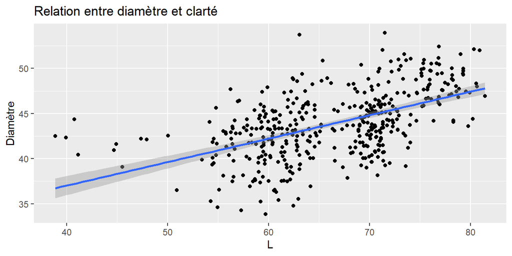

```r
fruit %>% ggplot() + aes(x=L,y=Diam) +
  geom_point() + geom_smooth(method='lm') +
  ggtitle("Relation entre diamètre et clarté") + xlab("L") + ylab("Diamètre")
```

## Corrélation

*Coefficient de corrélation* \(-1 \leq r \leq 1\) :

```r
cor(fruit$L,fruit$Diam)
```

```
[1] 0.535
```

Interprétation (à confirmer par graphique) :

- Si \(r \approx 1\) : relation linéaire croissante très forte
- Si \(r \approx -1\) : relation linéaire décroissante très forte
- Si \(r \approx 0\) : absence de lien linéaire

**Quelle est la variable la plus corrélée au taux de saccharose parmi le poids, le diamètre, L, a et b ?**

## Modèle de régression linéaire

**Estimation de la droite de régression**

```r
mod1 <- lm(Diam~L,data=fruit)
coef(mod1)
```

```
(Intercept)           L
      26.61        0.26
```

**Valeurs ajustées de la variable à expliquer**

```r
fruit$Diam_fit <- fitted(mod1)
fruit %>% slice(n=1) %>% kbl() %>% kable_paper(bootstrap_options = "striped")
```

|  | Poids | Diam | L | a | b | Glucose | Fructose | Saccharose | Citrate | Malate | Variete | Maturite | Diam_fit |
| --- | --- | --- | --- | --- | --- | --- | --- | --- | --- | --- | --- | --- | --- |
| 371p05 | 48 | 36.9 | 64.2 | -6.78 | 42.4 | 1.28 | 0.52 | 2.48 | 36.8 | 3.95 | 37 | Faible | 43.3 |

## Evaluation (graphique) de l’ajustement

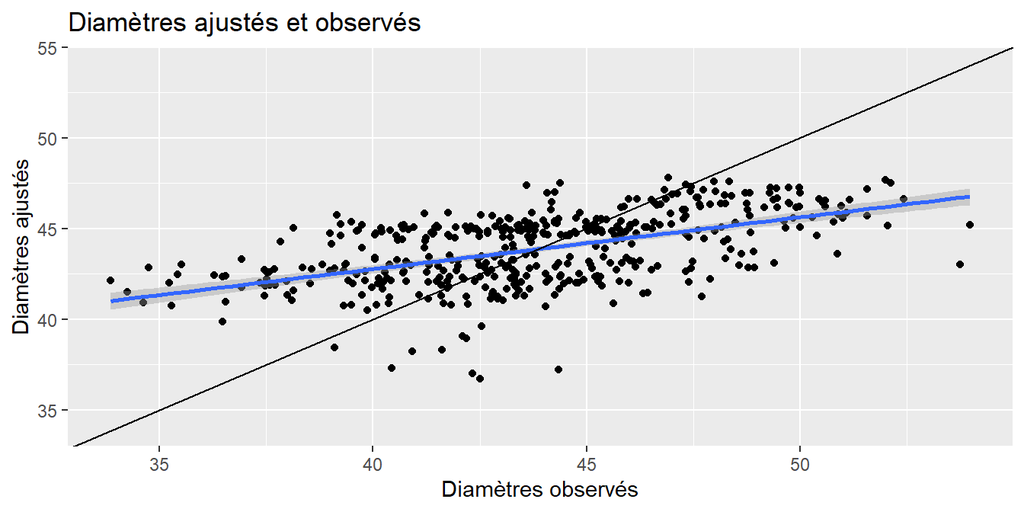

```r
fruit %>% ggplot(aes(x=Diam,y=Diam_fit)) + geom_point() + geom_smooth(method='lm') +
  ggtitle("Diamètres ajustés et observés") + geom_abline(intercept=0,slope=1) +
  xlab("Diamètres observés") + ylab("Diamètres ajustés") + ylim(34,54)
```

## Evaluation (numérique) de l’ajustement

\(\mathbf{R}^{2}\) : deux interprétations

```r
summary(mod1)$r.squared
```

```
[1] 0.286
```

```r
cor(fruit$Diam,fruit$Diam_fit)^2
```

```
[1] 0.286
```

```r
var(fruit$Diam_fit)/var(fruit$Diam)
```

```
[1] 0.286
```

## Test de Fisher

**Comparaison des modèles nul et alternatif**

```r
mod0 <- lm(Diam~1,data=fruit)
anova(mod0,mod1) %>% kbl(caption="Lien entre Clarté et Diamètre") %>%
  kable_paper(bootstrap_options = "striped", full_width = F)
```

Lien entre Clarté et Diamètre

| Res.Df | RSS | Df | Sum of Sq | F | Pr(>F) |
| --- | --- | --- | --- | --- | --- |
| 434 | 5988 | NA | NA | NA | NA |
| 433 | 4273 | 1 | 1714 | 174 | 0 |

**Conclusion** : la relation linéaire entre **diamètre** et **clarté** est significative au seuil de 5%,

## Prédiction

**Intervalle de confiance (95%) d’ajustement**

```r
new_fruit <- data.frame(L=c(40,60))
predict(mod1,newdata=new_fruit,interval="confidence")
```

```
   fit  lwr  upr
1 37.0 36.0 38.1
2 42.2 41.8 42.6
```

**Intervalle de confiance (95%) de prédiction**

```r
predict(mod1,newdata=new_fruit,interval="prediction")
```

```
   fit  lwr  upr
1 37.0 30.8 43.3
2 42.2 36.0 48.4
```

## Effet linéaire par groupes

```r
mod2 <- lm(Diam~L*Variete,data=fruit)
coef(mod2)
```

```
(Intercept)           L   Varietebl   Varietego
    41.1686     -0.0130      0.7273    -26.8698
  Varietemo L:Varietebl L:Varietego L:Varietemo
    -5.8875      0.0308      0.5015      0.1794
```

**Quelle est l’équation permettant de prédire Diam par L pour la variété A ? et pour la variété B ?**

## Equation unique ou équations par groupe ?

**Test de Fisher**

```r
anova(mod1,mod2) %>% kbl() %>%
  kable_paper(bootstrap_options = "striped", full_width = F)
```

| Res.Df | RSS | Df | Sum of Sq | F | Pr(>F) |
| --- | --- | --- | --- | --- | --- |
| 433 | 4273 | NA | NA | NA | NA |
| 427 | 2717 | 6 | 1556 | 40.8 | 0 |

## Comparaison de modèles

## Exemple : prédiction du taux de sucre d’un fruit

**Modèle de régression linéaire multiple**

```r
mod <- lm(Saccharose~Poids+Diam+L+a+b,data=fruit)
coef(mod)
```

```
(Intercept)       Poids        Diam           L
    -8.7835      0.0260     -0.0105      0.1783
          a           b
     0.0951     -0.0158
```

**Qualité d’ajustement**

```r
summary(mod)$r.squared
```

```
[1] 0.464
```

## Un des effets est-il significatif ?

**Test de Fisher**

```r
mod0 = lm(Saccharose~1,data=fruit)
anova(mod0,mod) %>% kbl(caption="Analyse de la variance") %>%
  kable_paper(bootstrap_options = "striped", full_width = F)
```

Analyse de la variance

| Res.Df | RSS | Df | Sum of Sq | F | Pr(>F) |
| --- | --- | --- | --- | --- | --- |
| 434 | 1141 | NA | NA | NA | NA |
| 429 | 612 | 5 | 529 | 74.2 | 0 |

**Quelle conclusion en tirer ?**

## Confusion d’effets

**Quels sont les effets à retenir ?**

```r
car::Anova(mod) %>% kbl() %>%
  kable_paper(bootstrap_options = "striped", full_width = F)
```

|  | Sum Sq | Df | F value | Pr(>F) |
| --- | --- | --- | --- | --- |
| Poids | 7.025 | 1 | 4.926 | 0.027 |
| Diam | 0.092 | 1 | 0.065 | 0.799 |
| L | 274.771 | 1 | 192.703 | 0.000 |
| a | 223.813 | 1 | 156.965 | 0.000 |
| b | 3.950 | 1 | 2.770 | 0.097 |
| Residuals | 611.702 | 429 | NA | NA |

**Le diamètre apporte-t’il une information sur le taux de sucre ?**

## Sélection des effets

## Choix du meilleur modele

**Quel choix de variables explicatives ?**

```r
bestmod <- regsubsets(Saccharose~Poids+Diam+L+a+b,data=fruit)
tidy(bestmod) %>% dplyr::select(1:7) %>%
  kbl(caption="Recherche exhaustive du meilleur modèle") %>%
  kable_paper(bootstrap_options = "striped", full_width = F)
```

Recherche exhaustive du meilleur modèle

| (Intercept) | Poids | Diam | L | a | b | r.squared |
| --- | --- | --- | --- | --- | --- | --- |
| TRUE | FALSE | TRUE | FALSE | FALSE | FALSE | 0.191 |
| TRUE | FALSE | FALSE | TRUE | TRUE | FALSE | 0.433 |
| TRUE | TRUE | FALSE | TRUE | TRUE | FALSE | 0.460 |
| TRUE | TRUE | FALSE | TRUE | TRUE | TRUE | 0.464 |
| TRUE | TRUE | TRUE | TRUE | TRUE | TRUE | 0.464 |

## Est-ce vraiment le meilleur choix ?

**Performance de prédiction : validation croisée**

```r
mod <- glm(Saccharose~Poids+Diam+L+a+b,data=fruit)
msep <- cv.glm(data=fruit,glmfit=mod,K=10)$delta
sqrt(msep)
```

```
[1] 1.21 1.21
```

**Selon vous, quel choix de variables explicatives pour une bonne prédiction du taux de sucre ?**

## Qualité d’ajustement

**BIC (Bayesian Information Criterion) et AIC (Akaike IC)** : qualité d’ajustement d’un modèle tenant compte de sa complexité (nombre de paramètres)

```r
tidy(bestmod) %>% dplyr::select(c(1:6,9)) %>%
  kbl(caption="Recherche exhaustive du meilleur modèle") %>%
  kable_paper(bootstrap_options = "striped", full_width = F)
```

Recherche exhaustive du meilleur modèle

| (Intercept) | Poids | Diam | L | a | b | BIC |
| --- | --- | --- | --- | --- | --- | --- |
| TRUE | FALSE | TRUE | FALSE | FALSE | FALSE | -79.9 |
| TRUE | FALSE | FALSE | TRUE | TRUE | FALSE | -228.5 |
| TRUE | TRUE | FALSE | TRUE | TRUE | FALSE | -244.0 |
| TRUE | TRUE | FALSE | TRUE | TRUE | TRUE | -240.7 |
| TRUE | TRUE | TRUE | TRUE | TRUE | TRUE | -234.7 |

## Sélection pas à pas

**Comment prédire au mieux le taux de saccharose ?**

```r
mod <- glm(Saccharose~Poids+Diam+L+a+b,data=fruit)
select <- stepwise(mod,direction="forward/backward",
                   criterion="BIC",trace=0)
```

```
Direction:  forward/backward
Criterion:  BIC
```

```r
coef(select)
```

[output not shown]

**Le sens de la recherche affecte-t’il le résultat ?**